Student number: 200594390

# Exploring the feedback from meditation app user after the meditation practice

#### A Data Programming Project

## 1 Aims, objectives and background

### 1.1 Introduction

Nowadays, more and more people pay attention to their health and mental status and wanted to stay healthy by practicing yoga. “In the past few years, meditation has hit the mainstream, joining the likes of yoga for improving physical and mental health.” [3] “Some businesses have already offered meditation training at work, while companies such as American Express, Ford, and LinkedIn hold employee-training sessions regularly.”[5] The value of the Meditation Market is increasing, “the meditation market’s revenue growth is up to $2.08 billion in 2022”.[5]

Given that I have been teaching yoga since 2019, I find it interesting to see the market's needs. The practice of yoga is an eight-stage process, the normal yoga practice for general yogi always only focuses on stage 1 to 4(Yamas, Niyama, Asana and Pranayama) which only practice the poses and breathing control. From stage 5 to 8( Pratyahara, Dharana, Dhyana and Samadhi) which is meditation level that represent a transcending process for the spirit aspects of yoga. It interests me to investigate the insight from a scientific method because yoga and meditation are the subjects, I am enthusiastic about and have been practicing for five years.

"People who seek to improve their well-being through meditation in general." [5] Using data science approaches, I aim to investigate how meditation may affect a person's performance. I'm going to employ natural language processing to analyze app reviews from mediation apps. In addition, analyze the information gathered as well to learn more slight.

### 1.2 Objectives

I want to investigate the following inside of this project:

**Establishing review measurements**

- Measuring attitude - how much positive and negative emotional language is in the reviews?
- Politeness - utilizing hedging phrases for response

**Analysing app review content**

- Is the user really enjoying and find it useful when using the mediation application?

**Analysing the statistic from research journal reports**

- How meditation effect human behaviour in work?

### 1.3 Aims

My aims for this project proposal are to:

- Collect the relevant datasets that should be used to provide analysis.
- Determine how much app review data is necessary to fully study the aforementioned issues, taking time and resource limits into account.
- Clean up and modify the data so that it can be used with the approaches use.
- Perform some exploratory data analysis to find any trends in the data that would make it worthwhile to explore further.

## 2 Data

### 2.1 Data source

There are five datasets in total for this project.

**The Association between Meditation Practice and Job Performance: A Cross-Sectional Study**

- JP1_Dataset.xlsx - This is an open reserach article published on December 16, 2015
- JP2_Dataset.xlsx - This is an open reserach article published on December 16, 2015

**Increased Gamma Brainwave Amplitude Compared to Control in Three Different Meditation Traditions**

- Gamma_med.csv - This is an open reserach article published on January 24, 2017

**Google Play Store Meditation App Reviews**

- playmeditopia_us.csv - This is an web scraped dataset, due date up to 2021

**App Store Meditation App Reviews**

- appstore_calm_us.csv - This is an web scraped dataset, due date up to 2021

### 2.2 Choice of Datasets

#### Selection for dataset about the effect from meditation practice

It is important to understand the market need. "As the latest meditation statistics show, its popularity is skyrocketing, with more and more people meditating on a regular basis. It’s estimated that 200–500 million people meditate worldwide."[4] I choose three datasets from:

- The Association between Meditation Practice and Job Performance: A Cross-Sectional Study
- Increased Gamma Brainwave Amplitude Compared to Control in Three Different Meditation Traditions

The purpose of the collected data is to draw some intriguing conclusions from a lengthy meditation experiment. The outcome can be quite persuasive because the dataset contains all available information.

#### Selection for dataset about the app

**Calm and Meditopia**

Calm and Meditopia is available in App store and Play store. It is one of the most popular apps since 2018. There are more than 10 million users downloaded. To see whether there are any differences, I will compare the reviews from the two platforms.

#### 2.2.1 Choice of Demographic for Meditation app review

I choose the reviews from US market only in order to get the English review for this project. The time period is from 2018 to 2021.

#### 2.2.2 Choice of methodology

The datasets are from the direct open source. They are the csv and xlsx files.

#### 2.2.3 Limitations and constraints of the data

**Not up to date time period**

The dataset of the app reviews from App store and Play store are web scraping databases. But the datasets are not up to date to 2022 as it is the direct source from kaggle.com.

### 2.3 Ethical considerations

#### 2.3.1 Use of Literature

All the research articles are open source, the content of the study paper can be used for eduction purpose.

#### 2.3.2 Use of data and derived data

All the data from the research articles are open source and can be downloaded without signing up. All the data from the app reviews are transparent in the app store and play store. The website that stored the web scraping data is possible for study purpose.

#### 2.3.3 Potential impacts of using data for the proposes analyses

Although no conclusions are used for any analysis, the study paper's data may serve as inspiration for this endeavor. I made my own analysis and conclusion using the data.  
The website's rating for the app review is excellent. Prior to the analysis, I am aware of this, but another goal of the study is to learn how the user experience made people feel. As a result, the rating does not introduce bias into the study.

### 2.4 Import libraries and modules

```python
# Import libraries and modules
import numpy as np
import pandas as pd
import matplotlib.pyplot as plt
import seaborn as sns
from nltk.tokenize import RegexpTokenizer
import nltk
from nltk.corpus import stopwords
from nltk.probability import FreqDist
from nltk.stem import WordNetLemmatizer
from nltk.tokenize import word_tokenize
from nltk.probability import FreqDist
import matplotlib.pyplot as plt
from wordcloud import WordCloud
from nltk.sentiment import SentimentIntensityAnalyzer

# Show all matplotlib graphs inline
%matplotlib inline
```

### 2.5 Import URLs

**The Association between Meditation Practice and Job Performance: A Cross-Sectional Study**

A population-based, cross-sectional survey targeting Japanese business people was conducted through the Internet in August 2014. Students and unemployed were excluded since the aim was to examine meditation in businesspersons.[1]

**1) Import the the first dataset** -- The final sample resulted in 30,664 participants.[1]

```python
JP1 = pd.read_excel('JP1_Dataset.xlsx')
```

```python
JP1.head()
```

|  | gender | age | Age Group | household income | education | meditation practice |
| --- | --- | --- | --- | --- | --- | --- |
| 0 | 2 | 59 | 5 | 1 | 1 | 0 |
| 1 | 1 | 59 | 5 | 1 | 1 | 0 |
| 2 | 1 | 59 | 5 | 3 | 1 | 0 |
| 3 | 1 | 59 | 5 | 2 | 1 | 0 |
| 4 | 1 | 59 | 5 | 2 | 1 | 0 |

```python
JP1.info()
```

```
<class 'pandas.core.frame.DataFrame'>
RangeIndex: 30665 entries, 0 to 30664
Data columns (total 6 columns):
 #   Column               Non-Null Count  Dtype
---  ------               --------------  -----
 0   gender               30665 non-null  int64
 1   age                  30665 non-null  int64
 2   Age Group            30665 non-null  int64
 3   household income     30665 non-null  int64
 4   education            30665 non-null  int64
 5   meditation practice  30665 non-null  int64
dtypes: int64(6)
memory usage: 1.4 MB
```

```python
JP2 = pd.read_excel('JP2_Dataset.xlsx')
```

```python
JP2.head()
```

|  | Gender | Age | HouseholdIncome | MaritalStatus | Education | SleepHours | SleepSufficiency | PhysicalActivityatWork | PhysicalActivityatLeisureTime | BMI | Stress | WE | HPQ | JobSaticefaction | FrequencyofMeditation |
| --- | --- | --- | --- | --- | --- | --- | --- | --- | --- | --- | --- | --- | --- | --- | --- |
| 0 | 1 | 45 | 1 | 2 | 2 | 4.0 | 1 | 3 | 2 | 24.221453 | 22 | 3.222222 | 3 | 27 | 3 |
| 1 | 2 | 54 | 3 | 4 | 3 | 6.0 | 2 | 1 | 3 | 28.040378 | 28 | 3.222222 | 4 | 23 | 1 |
| 2 | 2 | 42 | 3 | 1 | 4 | 5.0 | 2 | 2 | 5 | 23.337684 | 15 | 4.444444 | 8 | 39 | 1 |
| 3 | 2 | 50 | 3 | 2 | 4 | 6.5 | 2 | 2 | 2 | 21.303949 | 18 | 3.444444 | 7 | 33 | 1 |
| 4 | 2 | 32 | 2 | 1 | 4 | 6.0 | 2 | 1 | 4 | 18.827111 | 15 | 3.444444 | 8 | 28 | 1 |

```python
JP2.info()
```

```
<class 'pandas.core.frame.DataFrame'>
RangeIndex: 1470 entries, 0 to 1469
Data columns (total 15 columns):
 #   Column                         Non-Null Count  Dtype
---  ------                         --------------  -----
 0   Gender                         1470 non-null   int64
 1   Age                            1470 non-null   int64
 2   HouseholdIncome                1470 non-null   int64
 3   MaritalStatus                  1470 non-null   int64
 4   Education                      1470 non-null   int64
 5   SleepHours                     1470 non-null   float64
 6   SleepSufficiency               1470 non-null   int64
 7   PhysicalActivityatWork         1470 non-null   int64
 8   PhysicalActivityatLeisureTime  1470 non-null   int64
 9   BMI                            1470 non-null   float64
 10  Stress                         1470 non-null   int64
 11  WE                             1470 non-null   float64
 12  HPQ                            1470 non-null   int64
 13  JobSaticefaction               1470 non-null   int64
 14  FrequencyofMeditation          1470 non-null   int64
dtypes: float64(3), int64(12)
memory usage: 172.4 KB
```

**Increased Gamma Brainwave Amplitude Compared to Control in Three Different Meditation Traditions**

```python
Gamma_data = pd.read_csv('Gamma_med.csv')
```

```python
Gamma_data.head()
```

|  | Sujet | Type | Meditation Expe | Age | Median Gamma | Depth Med |
| --- | --- | --- | --- | --- | --- | --- |
| 0 | CTR11 | CTR | 0.0 | 30 | 30.3748 | 0.0 |
| 1 | CTR12 | CTR | 0.0 | 45 | 33.9095 | 0.0 |
| 2 | CTR13 | CTR | 0.0 | 50 | 26.6397 | 0.0 |
| 3 | CTR14 | CTR | 0.0 | 47 | 33.0826 | 0.0 |
| 4 | CTR15 | CTR | 0.0 | 36 | 34.5707 | 0.0 |

```python
Gamma_data.info()
```

```
<class 'pandas.core.frame.DataFrame'>
RangeIndex: 64 entries, 0 to 63
Data columns (total 6 columns):
 #   Column           Non-Null Count  Dtype
---  ------           --------------  -----
 0   Sujet            64 non-null     object
 1   Type             64 non-null     object
 2   Meditation Expe  64 non-null     float64
 3   Age              64 non-null     int64
 4   Median Gamma     64 non-null     float64
 5   Depth Med        64 non-null     float64
dtypes: float64(3), int64(1), object(2)
memory usage: 3.1+ KB
```

**Google Play Store Meditation App Reviews**

```python
playmeditopia_us = pd.read_csv('playmeditopia_us.csv')
```

```python
playmeditopia_us.head()
```

|  | Unnamed: 0 | reviewId | userName | userImage | content | score | thumbsUpCount | reviewCreatedVersion | at | replyContent | repliedAt |
| --- | --- | --- | --- | --- | --- | --- | --- | --- | --- | --- | --- |
| 0 | 0 | gp:AOqpTOEuHiXepchc_zH_yo8tfSmHHN8TCBXgXayrHL2... | Gordeh Man | https://play-lh.googleusercontent.com/-t41P6cc... | This app can be wonderfully helpful in dealing... | 5 | 9 | 3.14.1 | 2021-02-16 11:56:17 | Thank you so much for sharing your ideas with ... | 2021-02-18 16:18:41 |
| 1 | 1 | gp:AOqpTOFwY-lQRCIChJB3IJxeOHbZEeIuO4ZL1wg7uOy... | Ekaterine Khoperia | https://play-lh.googleusercontent.com/a-/AOh14... | Very balanced, needs oriented, user friendly a... | 5 | 5 | 3.14.1 | 2021-02-18 14:25:44 | NaN | NaN |
| 2 | 2 | gp:AOqpTOEz9cwfZZd9BxorlHiGFxQdD0SQa2TKc7KSFHl... | Michele Mazo | https://play-lh.googleusercontent.com/a-/AOh14... | I love this app. Learning to meditate is a pro... | 5 | 0 | 3.14.1 | 2021-02-18 20:09:16 | NaN | NaN |
| 3 | 3 | gp:AOqpTOFxrN5MbV_XF-IINxaupDuJycr3594wF08U_89... | Hanna W. - H. | https://play-lh.googleusercontent.com/a-/AOh14... | I have tried few meditation apps before. This ... | 5 | 55 | 3.13.1 | 2020-12-17 17:55:54 | NaN | NaN |
| 4 | 4 | gp:AOqpTOF0nGQPbduEuIzfB3RQU7ZnJI37E3TIDmL83xd... | Mary Lauzon | https://play-lh.googleusercontent.com/a-/AOh14... | I've many mental illness problems and this app... | 5 | 41 | 3.13.1 | 2020-12-23 21:16:31 | NaN | NaN |

```python
playmeditopia_us.info()
```

```
<class 'pandas.core.frame.DataFrame'>
RangeIndex: 1453 entries, 0 to 1452
Data columns (total 11 columns):
 #   Column                Non-Null Count  Dtype
---  ------                --------------  -----
 0   Unnamed: 0            1453 non-null   int64
 1   reviewId              1453 non-null   object
 2   userName              1453 non-null   object
 3   userImage             1453 non-null   object
 4   content               1453 non-null   object
 5   score                 1453 non-null   int64
 6   thumbsUpCount         1453 non-null   int64
 7   reviewCreatedVersion  1362 non-null   object
 8   at                    1453 non-null   object
 9   replyContent          124 non-null    object
 10  repliedAt             124 non-null    object
dtypes: int64(3), object(8)
memory usage: 125.0+ KB
```

**App Store Meditation App Reviews**

```python
appstore_calm_us = pd.read_csv('appstore_calm_us.csv')
```

```python
appstore_calm_us.head()
```

|  | Unnamed: 0 | date | rating | review |
| --- | --- | --- | --- | --- |
| 0 | 0 | 2020-12-06 05:17:39 | 5 | I updated the calm app and just out of curiosi... |
| 1 | 1 | 2020-09-21 22:38:20 | 3 | I really don’t like how you have to pay to get... |
| 2 | 2 | 2020-12-08 16:02:24 | 3 | I just wanted to leave a recommendation. Ther... |
| 3 | 3 | 2020-04-11 13:11:09 | 5 | I absolutely love love love this app!!!!♥️ onc... |
| 4 | 4 | 2020-05-24 19:52:55 | 4 | Honestly, I had come to a point in my life whe... |

```python
appstore_calm_us.info()
```

```
<class 'pandas.core.frame.DataFrame'>
RangeIndex: 1000 entries, 0 to 999
Data columns (total 4 columns):
 #   Column      Non-Null Count  Dtype
---  ------      --------------  -----
 0   Unnamed: 0  1000 non-null   int64
 1   date        1000 non-null   object
 2   rating      1000 non-null   int64
 3   review      1000 non-null   object
dtypes: int64(2), object(2)
memory usage: 31.4+ KB
```

## 3 Data cleaning and processing

### 3.1 Tokenization

Tokenization along with regular expressions can be done using NLTK's RegexpTokenizer. The majority of letters that can make up a word in any language, as well as digits and the underscore, are all recognized by w+ as Unicode word characters with one or more occurrences.

**Google Play Store Meditation App Reviews**

```python
regexp = RegexpTokenizer('\w+')
```

```python
playmeditopia_us['content_token']=playmeditopia_us['content'].apply(regexp.tokenize)
playmeditopia_us.head(3)
```

|  | Unnamed: 0 | reviewId | userName | userImage | content | score | thumbsUpCount | reviewCreatedVersion | at | replyContent | repliedAt | content_token |
| --- | --- | --- | --- | --- | --- | --- | --- | --- | --- | --- | --- | --- |
| 0 | 0 | gp:AOqpTOEuHiXepchc_zH_yo8tfSmHHN8TCBXgXayrHL2... | Gordeh Man | https://play-lh.googleusercontent.com/-t41P6cc... | This app can be wonderfully helpful in dealing... | 5 | 9 | 3.14.1 | 2021-02-16 11:56:17 | Thank you so much for sharing your ideas with ... | 2021-02-18 16:18:41 | [This, app, can, be, wonderfully, helpful, in,... |
| 1 | 1 | gp:AOqpTOFwY-lQRCIChJB3IJxeOHbZEeIuO4ZL1wg7uOy... | Ekaterine Khoperia | https://play-lh.googleusercontent.com/a-/AOh14... | Very balanced, needs oriented, user friendly a... | 5 | 5 | 3.14.1 | 2021-02-18 14:25:44 | NaN | NaN | [Very, balanced, needs, oriented, user, friend... |
| 2 | 2 | gp:AOqpTOEz9cwfZZd9BxorlHiGFxQdD0SQa2TKc7KSFHl... | Michele Mazo | https://play-lh.googleusercontent.com/a-/AOh14... | I love this app. Learning to meditate is a pro... | 5 | 0 | 3.14.1 | 2021-02-18 20:09:16 | NaN | NaN | [I, love, this, app, Learning, to, meditate, i... |

**App Store Meditation App Reviews**

```python
appstore_calm_us['review_token']=appstore_calm_us['review'].apply(regexp.tokenize)
appstore_calm_us.head(3)
```

|  | Unnamed: 0 | date | rating | review | review_token |
| --- | --- | --- | --- | --- | --- |
| 0 | 0 | 2020-12-06 05:17:39 | 5 | I updated the calm app and just out of curiosi... | [I, updated, the, calm, app, and, just, out, o... |
| 1 | 1 | 2020-09-21 22:38:20 | 3 | I really don’t like how you have to pay to get... | [I, really, don, t, like, how, you, have, to, ... |
| 2 | 2 | 2020-12-08 16:02:24 | 3 | I just wanted to leave a recommendation. Ther... | [I, just, wanted, to, leave, a, recommendation... |

### 3.2 Removing stop words

Stop words are terms in a stop list that are eliminated before natural language data analysis since they don't provide useful information (such as "am," "or," "has,"...").

```python
nltk.download()
```

```
showing info https://raw.githubusercontent.com/nltk/nltk_data/gh-pages/index.xml
```

```
True
```

```python
# Make a list of english stopwords
stopwords = nltk.corpus.stopwords.words("english")

# Extend the list my own custom stopwords - As meditation is the topic
my_stopwords = ['meditation']
stopwords.extend(my_stopwords)
```

### 3.2.1 Lambda

To eliminate the stopwords, we use a lambda function:

We convert text token's format to strings, keeping only words longer than two characters.

**Google Play Store Meditation App Reviews**

```python
playmeditopia_us['content_token'] = playmeditopia_us['content_token'].apply(lambda x: [item for item in x if item not in stopwords])
playmeditopia_us.head(3)
```

|  | Unnamed: 0 | reviewId | userName | userImage | content | score | thumbsUpCount | reviewCreatedVersion | at | replyContent | repliedAt | content_token |
| --- | --- | --- | --- | --- | --- | --- | --- | --- | --- | --- | --- | --- |
| 0 | 0 | gp:AOqpTOEuHiXepchc_zH_yo8tfSmHHN8TCBXgXayrHL2... | Gordeh Man | https://play-lh.googleusercontent.com/-t41P6cc... | This app can be wonderfully helpful in dealing... | 5 | 9 | 3.14.1 | 2021-02-16 11:56:17 | Thank you so much for sharing your ideas with ... | 2021-02-18 16:18:41 | [This, app, wonderfully, helpful, dealing, str... |
| 1 | 1 | gp:AOqpTOFwY-lQRCIChJB3IJxeOHbZEeIuO4ZL1wg7uOy... | Ekaterine Khoperia | https://play-lh.googleusercontent.com/a-/AOh14... | Very balanced, needs oriented, user friendly a... | 5 | 5 | 3.14.1 | 2021-02-18 14:25:44 | NaN | NaN | [Very, balanced, needs, oriented, user, friend... |
| 2 | 2 | gp:AOqpTOEz9cwfZZd9BxorlHiGFxQdD0SQa2TKc7KSFHl... | Michele Mazo | https://play-lh.googleusercontent.com/a-/AOh14... | I love this app. Learning to meditate is a pro... | 5 | 0 | 3.14.1 | 2021-02-18 20:09:16 | NaN | NaN | [I, love, app, Learning, meditate, process, ap... |

```python
playmeditopia_us['content_string'] = playmeditopia_us['content_token'].apply(lambda x: ' '.join([item for item in x if len(item)>2]))
```

```python
playmeditopia_us[['content', 'content_token', 'content_string']].head()
```

|  | content | content_token | content_string |
| --- | --- | --- | --- |
| 0 | This app can be wonderfully helpful in dealing... | [This, app, wonderfully, helpful, dealing, str... | This app wonderfully helpful dealing stress an... |
| 1 | Very balanced, needs oriented, user friendly a... | [Very, balanced, needs, oriented, user, friend... | Very balanced needs oriented user friendly use... |
| 2 | I love this app. Learning to meditate is a pro... | [I, love, app, Learning, meditate, process, ap... | love app Learning meditate process app provide... |
| 3 | I have tried few meditation apps before. This ... | [I, tried, apps, This, one, best, It, good, wi... | tried apps This one best good wide choice medi... |
| 4 | I've many mental illness problems and this app... | [I, many, mental, illness, problems, app, real... | many mental illness problems app really help a... |

**App Store Meditation App Reviews**

```python
appstore_calm_us['review_token'] = appstore_calm_us['review_token'].apply(lambda x: [item for item in x if item not in stopwords])
appstore_calm_us.head(3)
```

|  | Unnamed: 0 | date | rating | review | review_token |
| --- | --- | --- | --- | --- | --- |
| 0 | 0 | 2020-12-06 05:17:39 | 5 | I updated the calm app and just out of curiosi... | [I, updated, calm, app, curiosity, I, read, re... |
| 1 | 1 | 2020-09-21 22:38:20 | 3 | I really don’t like how you have to pay to get... | [I, really, like, pay, get, good, stuff, That,... |
| 2 | 2 | 2020-12-08 16:02:24 | 3 | I just wanted to leave a recommendation. Ther... | [I, wanted, leave, recommendation, There, ad, ... |

```python
appstore_calm_us['review_string'] = appstore_calm_us['review_token'].apply(lambda x: ' '.join([item for item in x if len(item)>2]))
```

```python
appstore_calm_us[['review', 'review_token', 'review_string']].head()
```

|  | review | review_token | review_string |
| --- | --- | --- | --- |
| 0 | I updated the calm app and just out of curiosi... | [I, updated, calm, app, curiosity, I, read, re... | updated calm app curiosity read reviews using ... |
| 1 | I really don’t like how you have to pay to get... | [I, really, like, pay, get, good, stuff, That,... | really like pay get good stuff That makes stre... |
| 2 | I just wanted to leave a recommendation. Ther... | [I, wanted, leave, recommendation, There, ad, ... | wanted leave recommendation There got seemed w... |
| 3 | I absolutely love love love this app!!!!♥️ onc... | [I, absolutely, love, love, love, app, I, coul... | absolutely love love love app could sleep turn... |
| 4 | Honestly, I had come to a point in my life whe... | [Honestly, I, come, point, life, I, insomnia, ... | Honestly come point life insomnia anxiety time... |

### 3.2.2 Tokenization

After that, we create a list of string and tokenize them.

**Google Play Store Meditation App Reviews**

```python
all_words_playmeditopia = ' '.join([word for word in playmeditopia_us['content_string']])
```

```python
tokenized_words_playmeditopia = nltk.tokenize.word_tokenize(all_words_playmeditopia)
```

**App Store Meditation App Reviews**

```python
all_words_appstore = ' '.join([word for word in appstore_calm_us['review_string']])
```

```python
tokenized_words_appstore = nltk.tokenize.word_tokenize(all_words_appstore)
```

### 3.2.3 FreqDist

Make a frequency distribution that shows how frequently each term has been used:

- We can now utilize our fdist dictionary to eliminate terms that appear fewer than a predetermined number of times.
- As the dataset is quite big, according to the result of the FreqDist, we filter out any words and set the value to greater or equal to 50 for Google Play Stoe and the value to greater or equal to 300 for App Store.

**Google Play Store Meditation App Reviews**

```python
fdist_playmeditopia = FreqDist(tokenized_words_playmeditopia)
fdist_playmeditopia
```

```
FreqDist({'app': 483, 'love': 132, 'good': 117, 'really': 113, 'This': 99, 'helps': 87, 'like': 82, 'Great': 81, 'Very': 79, 'feel': 76, ...})
```

```python
playmeditopia_us['content_string_fdist'] = playmeditopia_us['content_token'].apply(lambda x: ' '.join([item for item in x if fdist_playmeditopia[item] >= 50 ]))
```

```python
playmeditopia_us[['content', 'content_token', 'content_string', 'content_string_fdist']].head()
```

|  | content | content_token | content_string | content_string_fdist |
| --- | --- | --- | --- | --- |
| 0 | This app can be wonderfully helpful in dealing... | [This, app, wonderfully, helpful, dealing, str... | This app wonderfully helpful dealing stress an... | This app anxiety much |
| 1 | Very balanced, needs oriented, user friendly a... | [Very, balanced, needs, oriented, user, friend... | Very balanced needs oriented user friendly use... | Very great much app |
| 2 | I love this app. Learning to meditate is a pro... | [I, love, app, Learning, meditate, process, ap... | love app Learning meditate process app provide... | love app app best much |
| 3 | I have tried few meditation apps before. This ... | [I, tried, apps, This, one, best, It, good, wi... | tried apps This one best good wide choice medi... | This best good like The best app best free |
| 4 | I've many mental illness problems and this app... | [I, many, mental, illness, problems, app, real... | many mental illness problems app really help a... | app really help help sleep really help really ... |

**App Store Meditation App Reviews**

```python
fdist_appstore = FreqDist(tokenized_words_appstore)
fdist_appstore
```

```
FreqDist({'app': 2177, 'sleep': 878, 'Calm': 701, 'like': 579, 'stories': 555, 'The': 502, 'one': 463, 'would': 452, 'love': 439, 'day': 436, ...})
```

```python
appstore_calm_us['review_string_fdist'] = appstore_calm_us['review_token'].apply(lambda x: ' '.join([item for item in x if fdist_appstore[item] >= 300 ]))
```

```python
appstore_calm_us[['review', 'review_token', 'review_string', 'review_string_fdist']].head()
```

|  | review | review_token | review_string | review_string_fdist |
| --- | --- | --- | --- | --- |
| 0 | I updated the calm app and just out of curiosi... | [I, updated, calm, app, curiosity, I, read, re... | updated calm app curiosity read reviews using ... | calm app app love free get sleep stories get l... |
| 1 | I really don’t like how you have to pay to get... | [I, really, like, pay, get, good, stuff, That,... | really like pay get good stuff That makes stre... | really like get app Calm app free like day wou... |
| 2 | I just wanted to leave a recommendation. Ther... | [I, wanted, leave, recommendation, There, ad, ... | wanted leave recommendation There got seemed w... | The really app Calm help anxiety much app app ... |
| 3 | I absolutely love love love this app!!!!♥️ onc... | [I, absolutely, love, love, love, app, I, coul... | absolutely love love love app could sleep turn... | love love love app sleep calm sleep one day Th... |
| 4 | Honestly, I had come to a point in my life whe... | [Honestly, I, come, point, life, I, insomnia, ... | Honestly come point life insomnia anxiety time... | life anxiety time anxiety sleep get anxiety re... |

### 3.2.4 Lemmatization

Lemmatization is used in the following code to restore the original word form.

- To store the lemmatized list, we establish a new list of strings.
- Then, we determine whether there are any differences between the two lists or strings.
- The Google Play app review has 12 differences while the App Store review has no differences.
- Then, we call the dataset to show the dataframe table
- Finally, we combine the lemmatized string to a new string

**Google Play Store Meditation App Reviews**

```python
wordnet_lem_playmeditopia = WordNetLemmatizer()

playmeditopia_us['content_string_lem'] = playmeditopia_us['content_string_fdist'].apply(wordnet_lem_playmeditopia.lemmatize)
```

```python
# check if the columns are equal
playmeditopia_us['is_equal']= (playmeditopia_us['content_string_fdist']==playmeditopia_us['content_string_lem'])
```

```python
# show level count
playmeditopia_us.is_equal.value_counts()
```

```
True     1441
False      12
Name: is_equal, dtype: int64
```

```python
playmeditopia_us
```

|  | Unnamed: 0 | reviewId | userName | userImage | content | score | thumbsUpCount | reviewCreatedVersion | at | replyContent | repliedAt | content_token | content_string | content_string_fdist | content_string_lem | is_equal |
| --- | --- | --- | --- | --- | --- | --- | --- | --- | --- | --- | --- | --- | --- | --- | --- | --- |
| 0 | 0 | gp:AOqpTOEuHiXepchc_zH_yo8tfSmHHN8TCBXgXayrHL2... | Gordeh Man | https://play-lh.googleusercontent.com/-t41P6cc... | This app can be wonderfully helpful in dealing... | 5 | 9 | 3.14.1 | 2021-02-16 11:56:17 | Thank you so much for sharing your ideas with ... | 2021-02-18 16:18:41 | [This, app, wonderfully, helpful, dealing, str... | This app wonderfully helpful dealing stress an... | This app anxiety much | This app anxiety much | True |
| 1 | 1 | gp:AOqpTOFwY-lQRCIChJB3IJxeOHbZEeIuO4ZL1wg7uOy... | Ekaterine Khoperia | https://play-lh.googleusercontent.com/a-/AOh14... | Very balanced, needs oriented, user friendly a... | 5 | 5 | 3.14.1 | 2021-02-18 14:25:44 | NaN | NaN | [Very, balanced, needs, oriented, user, friend... | Very balanced needs oriented user friendly use... | Very great much app | Very great much app | True |
| 2 | 2 | gp:AOqpTOEz9cwfZZd9BxorlHiGFxQdD0SQa2TKc7KSFHl... | Michele Mazo | https://play-lh.googleusercontent.com/a-/AOh14... | I love this app. Learning to meditate is a pro... | 5 | 0 | 3.14.1 | 2021-02-18 20:09:16 | NaN | NaN | [I, love, app, Learning, meditate, process, ap... | love app Learning meditate process app provide... | love app app best much | love app app best much | True |
| 3 | 3 | gp:AOqpTOFxrN5MbV_XF-IINxaupDuJycr3594wF08U_89... | Hanna W. - H. | https://play-lh.googleusercontent.com/a-/AOh14... | I have tried few meditation apps before. This ... | 5 | 55 | 3.13.1 | 2020-12-17 17:55:54 | NaN | NaN | [I, tried, apps, This, one, best, It, good, wi... | tried apps This one best good wide choice medi... | This best good like The best app best free | This best good like The best app best free | True |
| 4 | 4 | gp:AOqpTOF0nGQPbduEuIzfB3RQU7ZnJI37E3TIDmL83xd... | Mary Lauzon | https://play-lh.googleusercontent.com/a-/AOh14... | I've many mental illness problems and this app... | 5 | 41 | 3.13.1 | 2020-12-23 21:16:31 | NaN | NaN | [I, many, mental, illness, problems, app, real... | many mental illness problems app really help a... | app really help help sleep really help really ... | app really help help sleep really help really ... | True |
| ... | ... | ... | ... | ... | ... | ... | ... | ... | ... | ... | ... | ... | ... | ... | ... | ... |
| 1448 | 1448 | gp:AOqpTOGm62fpnzJjcvND3m1gIbngyUKshPFn4fxu3oq... | Paulin Zambali | https://play-lh.googleusercontent.com/a-/AOh14... | Amazing | 5 | 0 | 3.12.2 | 2020-09-14 05:46:20 | NaN | NaN | [Amazing] | Amazing |  |  | True |
| 1449 | 1449 | gp:AOqpTOHMHHpMaA_8sp7CHAk4xMkwuz6w95E-UCld97o... | Basel Abusarhan | https://play-lh.googleusercontent.com/a-/AOh14... | Amazing | 5 | 0 | 3.12.2 | 2020-09-09 00:26:32 | NaN | NaN | [Amazing] | Amazing |  |  | True |
| 1450 | 1450 | gp:AOqpTOF6QLyWyxizrdv8pdQAjfqhGpPm2SUsgcrZa75... | Imani Rene | https://play-lh.googleusercontent.com/-WKJy2WL... | Good | 5 | 0 | NaN | 2020-12-30 07:41:24 | NaN | NaN | [Good] | Good |  |  | True |
| 1451 | 1451 | gp:AOqpTOEOyXaFZ0DYMVi0NlPXF4jWG3QV3LuT0-v49B4... | Fatum aghani | https://play-lh.googleusercontent.com/a-/AOh14... | EXCELLENT | 5 | 0 | NaN | 2019-05-11 21:16:49 | NaN | NaN | [EXCELLENT] | EXCELLENT |  |  | True |
| 1452 | 1452 | gp:AOqpTOH7GMZ0NLGB7NQ37gf78SEW30oOx-mvIZaVMBa... | Malaquias Wallace | https://play-lh.googleusercontent.com/a-/AOh14... | Refreshing | 5 | 0 | 3.12.2 | 2020-08-26 07:30:01 | NaN | NaN | [Refreshing] | Refreshing |  |  | True |

1453 rows × 16 columns

```python
all_words_lem_playmeditopia = ' '.join([word for word in playmeditopia_us['content_string_lem']])
```

**App Store Meditation App Reviews**

```python
wordnet_lem_appstore = WordNetLemmatizer()

appstore_calm_us['review_string_lem'] = appstore_calm_us['review_string_fdist'].apply(wordnet_lem_appstore.lemmatize)
```

```python
appstore_calm_us['is_equal']= (appstore_calm_us['review_string_fdist']==appstore_calm_us['review_string_lem'])
```

```python
appstore_calm_us.is_equal.value_counts()
```

```
True    1000
Name: is_equal, dtype: int64
```

```python
appstore_calm_us
```

|  | Unnamed: 0 | date | rating | review | review_token | review_string | review_string_fdist | review_string_lem | is_equal |
| --- | --- | --- | --- | --- | --- | --- | --- | --- | --- |
| 0 | 0 | 2020-12-06 05:17:39 | 5 | I updated the calm app and just out of curiosi... | [I, updated, calm, app, curiosity, I, read, re... | updated calm app curiosity read reviews using ... | calm app app love free get sleep stories get l... | calm app app love free get sleep stories get l... | True |
| 1 | 1 | 2020-09-21 22:38:20 | 3 | I really don’t like how you have to pay to get... | [I, really, like, pay, get, good, stuff, That,... | really like pay get good stuff That makes stre... | really like get app Calm app free like day wou... | really like get app Calm app free like day wou... | True |
| 2 | 2 | 2020-12-08 16:02:24 | 3 | I just wanted to leave a recommendation. Ther... | [I, wanted, leave, recommendation, There, ad, ... | wanted leave recommendation There got seemed w... | The really app Calm help anxiety much app app ... | The really app Calm help anxiety much app app ... | True |
| 3 | 3 | 2020-04-11 13:11:09 | 5 | I absolutely love love love this app!!!!♥️ onc... | [I, absolutely, love, love, love, app, I, coul... | absolutely love love love app could sleep turn... | love love love app sleep calm sleep one day Th... | love love love app sleep calm sleep one day Th... | True |
| 4 | 4 | 2020-05-24 19:52:55 | 4 | Honestly, I had come to a point in my life whe... | [Honestly, I, come, point, life, I, insomnia, ... | Honestly come point life insomnia anxiety time... | life anxiety time anxiety sleep get anxiety re... | life anxiety time anxiety sleep get anxiety re... | True |
| ... | ... | ... | ... | ... | ... | ... | ... | ... | ... |
| 995 | 995 | 2018-12-29 03:43:43 | 5 | I want a refund for my subscription. I paid fo... | [I, want, refund, subscription, I, paid, year,... | want refund subscription paid year subscriptio... | app would app | app would app | True |
| 996 | 996 | 2018-12-03 12:32:23 | 5 | I was diagnosed with severe anxiety a few year... | [I, diagnosed, severe, anxiety, years, ago, No... | diagnosed severe anxiety years ago Nothing rea... | anxiety really app like one time | anxiety really app like one time | True |
| 997 | 997 | 2018-07-15 23:35:19 | 5 | Honestly I had never really meditated before b... | [Honestly, I, never, really, meditated, I, alw... | Honestly never really meditated always curious... | really meditations calm much calm would | really meditations calm much calm would | True |
| 998 | 998 | 2018-11-12 23:42:31 | 1 | Seriously only a seven day free trial. How are... | [Seriously, seven, day, free, trial, How, supp... | Seriously seven day free trial How supposed te... | day free help help life like life free app | day free help help life like life free app | True |
| 999 | 999 | 2018-04-17 00:14:07 | 4 | Overall, this app is pretty amazing. I suffer ... | [Overall, app, pretty, amazing, I, suffer, ser... | Overall app pretty amazing suffer serious anxi... | app anxiety app help really help app app | app anxiety app help really help app app | True |

1000 rows × 9 columns

```python
all_words_lem_appstore = ' '.join([word for word in appstore_calm_us['review_string_lem']])
```

### 4 Generating features

### 4.1 Frequency distributions

- The lemmization list is first tokenized.
- After that, find the frequency distributions by categorizing.
- In that set of strings, we test the five most frequent words.

**Google Play Store Meditation App Reviews**

```python
words_playmeditopia = nltk.word_tokenize(all_words_lem_playmeditopia)
fd_playmeditopia = FreqDist(words_playmeditopia)
```

```python
fd_playmeditopia.most_common(5)
```

```
[('app', 483), ('love', 132), ('good', 117), ('really', 113), ('This', 99)]
```

```python
fd_playmeditopia.tabulate(5)
```

```
   app   love   good really   This
   483    132    117    113     99
```

**App Store Meditation App Reviews**

```python
words_appstore = nltk.word_tokenize(all_words_lem_appstore)
fd_appstore = FreqDist(words_appstore)
```

```python
fd_appstore.most_common(5)
```

```
[('app', 2177), ('sleep', 878), ('Calm', 701), ('like', 579), ('stories', 555)]
```

```python
fd_appstore.tabulate(5)
```

```
    app   sleep    Calm    like stories
   2177     878     701     579     555
```

### 4.2 Seaborn

The top 10 most frequent words in these two app platforms are shown in the charts below.

**Google Play Store Meditation App Reviews**

The word count of common words is represented on the x axis, and the top 10 words are represented on the y axis.

```python
# Obtain top 10 words
top_10_playmeditopia = fd_playmeditopia.most_common(10)

# Create pandas series to make plotting easier
fdist_playmeditopia = pd.Series(dict(top_10_playmeditopia))
```

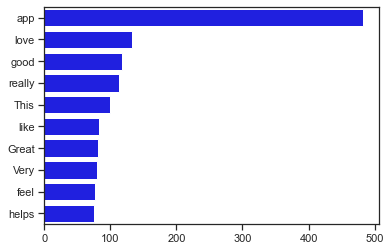

```python
sns.set_theme(style="ticks")

sns.barplot(y=fdist_playmeditopia.index, x=fdist_playmeditopia.values, color='blue');
```

**App Store Meditation App Reviews**

The word count of common words is represented on the x axis, and the top 10 words are represented on the y axis.

```python
# Obtain top 10 words
top_10_appstore = fd_appstore.most_common(10)

# Create pandas series to make plotting easier
fdist_appstore = pd.Series(dict(top_10_appstore))
```

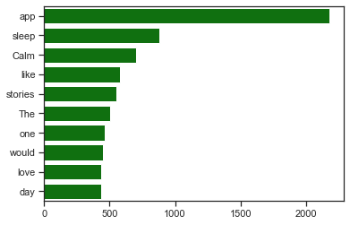

```python
sns.set_theme(style="ticks")

sns.barplot(y=fdist_appstore.index, x=fdist_appstore.values, color='green');
```

We can observe that the words "app," "like," and "love" are presented in both results. Sleep is the second most popular word in the app store, and it caught my eye. In chapter 5.6, I would conduct another visual examination relating to sleep.

### 4.3 Sentiment Intensity Analysis

I will use Sentiment Intensity Analysis to computate whether the reviews are positive, negative or neutral.

**Google Play Store Meditation App Reviews**

```python
analyzer = SentimentIntensityAnalyzer()
```

To save the polarity scores produced by content_string_lem, we first establish a new list. Then we remove any unneeded lists, like "Unnamed: 0," "reviewId," "userName," and "userImage." Change the data structure to "neg," "neu," "pos," and "compound" by using apply(pd.Series). When the dataset is finally generated a second attempt, a new list called "sentiment" will be created and used to store the playmeditopia_us score results.

```python
playmeditopia_us['polarity'] = playmeditopia_us['content_string_lem'].apply(lambda x: analyzer.polarity_scores(x))
playmeditopia_us.head(3)
```

|  | Unnamed: 0 | reviewId | userName | userImage | content | score | thumbsUpCount | reviewCreatedVersion | at | replyContent | repliedAt | content_token | content_string | content_string_fdist | content_string_lem | is_equal | polarity |
| --- | --- | --- | --- | --- | --- | --- | --- | --- | --- | --- | --- | --- | --- | --- | --- | --- | --- |
| 0 | 0 | gp:AOqpTOEuHiXepchc_zH_yo8tfSmHHN8TCBXgXayrHL2... | Gordeh Man | https://play-lh.googleusercontent.com/-t41P6cc... | This app can be wonderfully helpful in dealing... | 5 | 9 | 3.14.1 | 2021-02-16 11:56:17 | Thank you so much for sharing your ideas with ... | 2021-02-18 16:18:41 | [This, app, wonderfully, helpful, dealing, str... | This app wonderfully helpful dealing stress an... | This app anxiety much | This app anxiety much | True | {'neg': 0.362, 'neu': 0.638, 'pos': 0.0, 'comp... |
| 1 | 1 | gp:AOqpTOFwY-lQRCIChJB3IJxeOHbZEeIuO4ZL1wg7uOy... | Ekaterine Khoperia | https://play-lh.googleusercontent.com/a-/AOh14... | Very balanced, needs oriented, user friendly a... | 5 | 5 | 3.14.1 | 2021-02-18 14:25:44 | NaN | NaN | [Very, balanced, needs, oriented, user, friend... | Very balanced needs oriented user friendly use... | Very great much app | Very great much app | True | {'neg': 0.0, 'neu': 0.406, 'pos': 0.594, 'comp... |
| 2 | 2 | gp:AOqpTOEz9cwfZZd9BxorlHiGFxQdD0SQa2TKc7KSFHl... | Michele Mazo | https://play-lh.googleusercontent.com/a-/AOh14... | I love this app. Learning to meditate is a pro... | 5 | 0 | 3.14.1 | 2021-02-18 20:09:16 | NaN | NaN | [I, love, app, Learning, meditate, process, ap... | love app Learning meditate process app provide... | love app app best much | love app app best much | True | {'neg': 0.0, 'neu': 0.263, 'pos': 0.737, 'comp... |

```python
# Change data structure
playmeditopia_us = pd.concat(
    [playmeditopia_us.drop(['Unnamed: 0', 'reviewId', 'userName', 'userImage','polarity' ], axis=1),
     playmeditopia_us['polarity'].apply(pd.Series)], axis=1)
playmeditopia_us.head(3)
```

|  | content | score | thumbsUpCount | reviewCreatedVersion | at | replyContent | repliedAt | content_token | content_string | content_string_fdist | content_string_lem | is_equal | neg | neu | pos | compound |
| --- | --- | --- | --- | --- | --- | --- | --- | --- | --- | --- | --- | --- | --- | --- | --- | --- |
| 0 | This app can be wonderfully helpful in dealing... | 5 | 9 | 3.14.1 | 2021-02-16 11:56:17 | Thank you so much for sharing your ideas with ... | 2021-02-18 16:18:41 | [This, app, wonderfully, helpful, dealing, str... | This app wonderfully helpful dealing stress an... | This app anxiety much | This app anxiety much | True | 0.362 | 0.638 | 0.000 | -0.1779 |
| 1 | Very balanced, needs oriented, user friendly a... | 5 | 5 | 3.14.1 | 2021-02-18 14:25:44 | NaN | NaN | [Very, balanced, needs, oriented, user, friend... | Very balanced needs oriented user friendly use... | Very great much app | Very great much app | True | 0.000 | 0.406 | 0.594 | 0.6590 |
| 2 | I love this app. Learning to meditate is a pro... | 5 | 0 | 3.14.1 | 2021-02-18 20:09:16 | NaN | NaN | [I, love, app, Learning, meditate, process, ap... | love app Learning meditate process app provide... | love app app best much | love app app best much | True | 0.000 | 0.263 | 0.737 | 0.8555 |

```python
playmeditopia_us['sentiment'] = playmeditopia_us['compound'].apply(lambda x: 'positive' if x >0 else 'neutral' if x==0 else 'negative')
playmeditopia_us.head(3)
```

|  | content | score | thumbsUpCount | reviewCreatedVersion | at | replyContent | repliedAt | content_token | content_string | content_string_fdist | content_string_lem | is_equal | neg | neu | pos | compound | sentiment |
| --- | --- | --- | --- | --- | --- | --- | --- | --- | --- | --- | --- | --- | --- | --- | --- | --- | --- |
| 0 | This app can be wonderfully helpful in dealing... | 5 | 9 | 3.14.1 | 2021-02-16 11:56:17 | Thank you so much for sharing your ideas with ... | 2021-02-18 16:18:41 | [This, app, wonderfully, helpful, dealing, str... | This app wonderfully helpful dealing stress an... | This app anxiety much | This app anxiety much | True | 0.362 | 0.638 | 0.000 | -0.1779 | negative |
| 1 | Very balanced, needs oriented, user friendly a... | 5 | 5 | 3.14.1 | 2021-02-18 14:25:44 | NaN | NaN | [Very, balanced, needs, oriented, user, friend... | Very balanced needs oriented user friendly use... | Very great much app | Very great much app | True | 0.000 | 0.406 | 0.594 | 0.6590 | positive |
| 2 | I love this app. Learning to meditate is a pro... | 5 | 0 | 3.14.1 | 2021-02-18 20:09:16 | NaN | NaN | [I, love, app, Learning, meditate, process, ap... | love app Learning meditate process app provide... | love app app best much | love app app best much | True | 0.000 | 0.263 | 0.737 | 0.8555 | positive |

**App Store Meditation App Reviews**

To save the polarity scores produced by review_string_lem, we first establish a new list. Then we remove any unneeded lists, like "Unnamed: 0", "is_equal","polarity". Change the data structure to "neg," "neu," "pos," and "compound" by using apply(pd.Series). When the dataset is finally generated a second attempt, a new list called "sentiment" will be created and used to store the appstore_calm_u score results.

```python
appstore_calm_us['polarity'] = appstore_calm_us['review_string_lem'].apply(lambda x: analyzer.polarity_scores(x))
appstore_calm_us.tail(3)
```

|  | Unnamed: 0 | date | rating | review | review_token | review_string | review_string_fdist | review_string_lem | is_equal | polarity |
| --- | --- | --- | --- | --- | --- | --- | --- | --- | --- | --- |
| 997 | 997 | 2018-07-15 23:35:19 | 5 | Honestly I had never really meditated before b... | [Honestly, I, never, really, meditated, I, alw... | Honestly never really meditated always curious... | really meditations calm much calm would | really meditations calm much calm would | True | {'neg': 0.0, 'neu': 0.437, 'pos': 0.563, 'comp... |
| 998 | 998 | 2018-11-12 23:42:31 | 1 | Seriously only a seven day free trial. How are... | [Seriously, seven, day, free, trial, How, supp... | Seriously seven day free trial How supposed te... | day free help help life like life free app | day free help help life like life free app | True | {'neg': 0.0, 'neu': 0.216, 'pos': 0.784, 'comp... |
| 999 | 999 | 2018-04-17 00:14:07 | 4 | Overall, this app is pretty amazing. I suffer ... | [Overall, app, pretty, amazing, I, suffer, ser... | Overall app pretty amazing suffer serious anxi... | app anxiety app help really help app app | app anxiety app help really help app app | True | {'neg': 0.14, 'neu': 0.413, 'pos': 0.446, 'com... |

```python
# Change data structure
appstore_calm_us = pd.concat(
    [appstore_calm_us.drop(['Unnamed: 0', 'is_equal','polarity'], axis=1),
     appstore_calm_us['polarity'].apply(pd.Series)], axis=1)
appstore_calm_us.head(3)
```

|  | date | rating | review | review_token | review_string | review_string_fdist | review_string_lem | neg | neu | pos | compound |
| --- | --- | --- | --- | --- | --- | --- | --- | --- | --- | --- | --- |
| 0 | 2020-12-06 05:17:39 | 5 | I updated the calm app and just out of curiosi... | [I, updated, calm, app, curiosity, I, read, re... | updated calm app curiosity read reviews using ... | calm app app love free get sleep stories get l... | calm app app love free get sleep stories get l... | 0.000 | 0.354 | 0.646 | 0.9274 |
| 1 | 2020-09-21 22:38:20 | 3 | I really don’t like how you have to pay to get... | [I, really, like, pay, get, good, stuff, That,... | really like pay get good stuff That makes stre... | really like get app Calm app free like day wou... | really like get app Calm app free like day wou... | 0.000 | 0.432 | 0.568 | 0.9669 |
| 2 | 2020-12-08 16:02:24 | 3 | I just wanted to leave a recommendation. Ther... | [I, wanted, leave, recommendation, There, ad, ... | wanted leave recommendation There got seemed w... | The really app Calm help anxiety much app app ... | The really app Calm help anxiety much app app ... | 0.092 | 0.431 | 0.477 | 0.7988 |

```python
appstore_calm_us['sentiment'] = appstore_calm_us['compound'].apply(lambda x: 'positive' if x >0 else 'neutral' if x==0 else 'negative')
appstore_calm_us.head(3)
```

|  | date | rating | review | review_token | review_string | review_string_fdist | review_string_lem | neg | neu | pos | compound | sentiment |
| --- | --- | --- | --- | --- | --- | --- | --- | --- | --- | --- | --- | --- |
| 0 | 2020-12-06 05:17:39 | 5 | I updated the calm app and just out of curiosi... | [I, updated, calm, app, curiosity, I, read, re... | updated calm app curiosity read reviews using ... | calm app app love free get sleep stories get l... | calm app app love free get sleep stories get l... | 0.000 | 0.354 | 0.646 | 0.9274 | positive |
| 1 | 2020-09-21 22:38:20 | 3 | I really don’t like how you have to pay to get... | [I, really, like, pay, get, good, stuff, That,... | really like pay get good stuff That makes stre... | really like get app Calm app free like day wou... | really like get app Calm app free like day wou... | 0.000 | 0.432 | 0.568 | 0.9669 | positive |
| 2 | 2020-12-08 16:02:24 | 3 | I just wanted to leave a recommendation. Ther... | [I, wanted, leave, recommendation, There, ad, ... | wanted leave recommendation There got seemed w... | The really app Calm help anxiety much app app ... | The really app Calm help anxiety much app app ... | 0.092 | 0.431 | 0.477 | 0.7988 | positive |

## 5 Exploratory data analysis

### 5.1 Analyze data from sentiment

In the following, we tweet the highest positive and highest negative sentiment for Google Play Store review and App Store review respectively.

**Google Play Store Meditation App Reviews**

```python
# Tweet with highest positive sentiment
playmeditopia_us.loc[playmeditopia_us['compound'].idxmax()].values
```

```
array(["I just love it so so so so much you should definitely get it it's so awesome just click the back button so you don't have to pay anything and then you just listen to stories the stories are my very favorite I've looked and looked and looked everywhere for good books and audios but no these a…
       5, 45, '3.10.6', '2020-05-20 01:42:00', nan, nan,
       list(['I', 'love', 'much', 'definitely', 'get', 'awesome', 'click', 'back', 'button', 'pay', 'anything', 'listen', 'stories', 'stories', 'favorite', 'I', 'looked', 'looked', 'looked', 'everywhere', 'good', 'books', 'audios', 'best', 'I', 'done', 'every', 'single', 'one', 'I', 'love', 'much', …
       'love much definitely get awesome click back button pay anything listen stories stories favorite looked looked looked everywhere good books audios best done every single one love much makes cry like sad ones feel good good app ever5',
       'love much good best love much like feel good good app',
       'love much good best love much like feel good good app', True, 0.0,
       0.144, 0.856, 0.9744, 'positive'], dtype=object)
```

```python
# Tweet with highest negative sentiment
# ...seems to be a case of wrong classification because of the word "deficit"
playmeditopia_us.loc[playmeditopia_us['compound'].idxmin()].values
```

```
array(['I had been experiencing an increasing amount of anxiety over the past 4 years including tightness in my chest, heart palpitations and irritability. I have been using this app for several months now and it has become one of the things I do for self care that has helped me manage my anxiety, e…
       5, 2, '3.12.11', '2020-12-04 20:18:42', nan, nan,
       list(['I', 'experiencing', 'increasing', 'amount', 'anxiety', 'past', '4', 'years', 'including', 'tightness', 'chest', 'heart', 'palpitations', 'irritability', 'I', 'using', 'app', 'several', 'months', 'become', 'one', 'things', 'I', 'self', 'care', 'helped', 'manage', 'anxiety', 'etc', 'Than…
       'experiencing increasing amount anxiety past years including tightness chest heart palpitations irritability using app several months become one things self care helped manage anxiety etc Thank Meditopia improving quality life',
       'anxiety app anxiety', 'anxiety app anxiety', True, 0.773, 0.227,
       0.0, -0.34, 'negative'], dtype=object)
```

**App Store Meditation App Reviews**

```python
# Tweet with highest positive sentiment
appstore_calm_us.loc[appstore_calm_us['compound'].idxmax()].values
```

```
array(['2017-08-30 13:53:00', 5,
       "I love this app for so many reasons. I love the appearance of the app, I love the different backgrounds and music that you can choose. I love that you can choose meditations based on how you are feeling and what you need at the moment. I love how the calendar keeps track of your meditation p…
       list(['I', 'love', 'app', 'many', 'reasons', 'I', 'love', 'appearance', 'app', 'I', 'love', 'different', 'backgrounds', 'music', 'choose', 'I', 'love', 'choose', 'meditations', 'based', 'feeling', 'need', 'moment', 'I', 'love', 'calendar', 'keeps', 'track', 'practice', 'especially', 'nice', '…
       'love app many reasons love appearance app love different backgrounds music choose love choose meditations based feeling need moment love calendar keeps track practice especially nice let know multi day streak makes even likely meditate like reward see pop love daily quote pops love mindfulne…
       'love app love app love love meditations love day like love love love meditations love stories This app',
       'love app love app love love meditations love day like love love love meditations love stories This app',
       0.0, 0.166, 0.834, 0.9919, 'positive'], dtype=object)
```

```python
# Tweet with highest negative sentiment
# ...seems to be a case of wrong classification because of the word "deficit"
appstore_calm_us.loc[appstore_calm_us['compound'].idxmin()].values
```

```
array(['2020-09-08 22:46:01', 3,
       'I got a year of premium on this app and absolutely adore it. The depth, care, and detail that went into making this app the best of its kind are not at all lost on me. It’s been very helpful to me with managing sleep and anxiety, really to life-changing levels. But I find my biggest complain…
       list(['I', 'got', 'year', 'premium', 'app', 'absolutely', 'adore', 'The', 'depth', 'care', 'detail', 'went', 'making', 'app', 'best', 'kind', 'lost', 'It', 'helpful', 'managing', 'sleep', 'anxiety', 'really', 'life', 'changing', 'levels', 'But', 'I', 'find', 'biggest', 'complaint', 'thing', '…
       'got year premium app absolutely adore The depth care detail went making app best kind lost helpful managing sleep anxiety really life changing levels But find biggest complaint thing makes bouts stop using altogether lack variety narrators Tamara Levitt used narrate large number exercises vo…
       'app The app sleep anxiety really life really app really much anxiety sleep would really sleep anxiety',
       'app The app sleep anxiety really life really app really much anxiety sleep would really sleep anxiety',
       0.267, 0.733, 0.0, -0.4767, 'negative'], dtype=object)
```

It's also known as opinion mining, deriving the opinion or attitude of a speaker.

### 5.2 Visualize data from sentiment

The following are the data visualized from the sentiment:

**Google Play Store Meditation App Reviews**

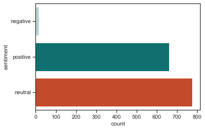

```python
# Number of tweets
sns.countplot(y='sentiment',
             data=playmeditopia_us,
             palette=['#b2d8d8',"#008080", '#db3d13']
             );
```

**App Store Meditation App Reviews**

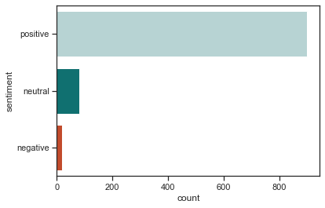

```python
sns.countplot(y='sentiment',
             data=appstore_calm_us,
             palette=['#b2d8d8',"#008080", '#db3d13']
             );
```

It's interesting to note that the outcomes from these two app store platforms vary in various ways. It is normal for the negative count to be low. Unexpectedly, more users have left indifferent reviews on the Play Store than have left positive reviews. And the app store user reviews were far more favorable. Could this indicate that App store users are more giving overall?

### 5.3 Wordclouds

For play store and app store reviews, there are two different types of world cloud visualization. The first is a mask in the shape of a circle, while the second is a typical rectangle. The most frequent words will be displayed on a graphic in descending order of word size.

**Google Play Store Meditation App Reviews**

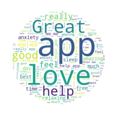

```python
x, y = np.ogrid[:300, :300]
mask = (x - 150) ** 2 + (y - 150) ** 2 > 130 ** 2
mask = 255 * mask.astype(int)

wc = WordCloud(background_color="white", repeat=True, mask=mask)
wc.generate(all_words_lem_playmeditopia)

plt.axis("off")
plt.imshow(wc, interpolation="bilinear");
```

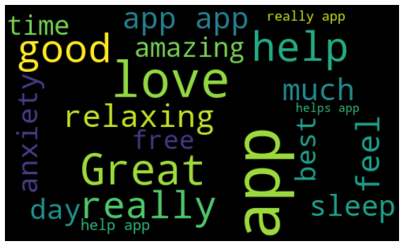

```python
wordcloud = WordCloud(width=500,
                     height=300,
                     random_state=2,
                     max_font_size=80).generate(all_words_lem_playmeditopia)

plt.figure(figsize=(10, 7))
plt.imshow(wordcloud, interpolation='bilinear')
plt.axis('off');
```

**App Store Meditation App Reviews**

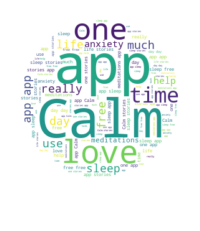

```python
x, y = np.ogrid[:350, :300]
mask = (x - 150) ** 2 + (y - 150) ** 2 > 130 ** 2
mask = 255 * mask.astype(int)

wc = WordCloud(background_color="white", repeat=True, mask=mask)
wc.generate(all_words_lem_appstore)

plt.axis("off")
plt.imshow(wc, interpolation="bilinear");
```

[figure not shown]

```python
wordcloud = WordCloud(width=500,
                     height=300,
                     random_state=2,
                     max_font_size=80).generate(all_words_lem_appstore)

plt.figure(figsize=(10, 7))
plt.imshow(wordcloud, interpolation='bilinear')
plt.axis('off');
```

We can see from the images above that the text on the images generally receives favorable responses. It may infer inadvertently that the user is satisfied with the result of their interaction. And the meditation app is actually helpful and can meet the user's needs.

### 5.4 Gamma Brainwave Amplitude in Seaborn

In the following graph, y axis represent the median gamma amplitude, x axis represent the meditation experience. It is classified into 4 group of participants.

- CTR = Control group (non traditional meditation)
- HYT = Himalayan Yoga (traditional meditation style type)
- ISY = Isha Shoonya (traditional meditation style type)
- VIP = Vipassana (traditional meditation style type)

```python
sns.set(style="ticks", color_codes=True)
```

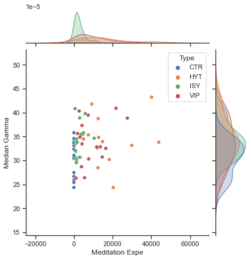

```python
sns.jointplot(y="Median Gamma", x="Meditation Expe",hue="Type", data=Gamma_data);
```

### 5.5 Meditation Practice and Job Performance Study 1

**Study 1 is from the JP1 dataset**

- In the following graph, x axis represent the household income level, the higher number, the higher income. y axis represent the age, hue represent meditation practice where 0 = no meditation practice, 1 = has meditation practice.

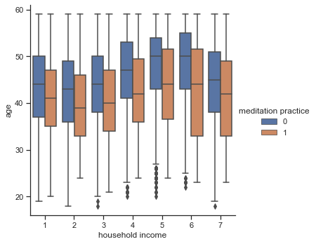

```python
sns.catplot(x="household income", y="age", hue="meditation practice", kind="box", data=JP1)
plt.xticks(rotation=0)
plt.show()
```

It's noteworthy to note that people who practice meditation make the same amount of money for the household income in a more younger age in general.

### 5.6 Meditation Practice and Job Performance Study 2

**Study 2 is from the JP2 dataset**

- There is a substantially wider variety of data types in the JP2 dataset. All of the study's categories are displayed in the box below.

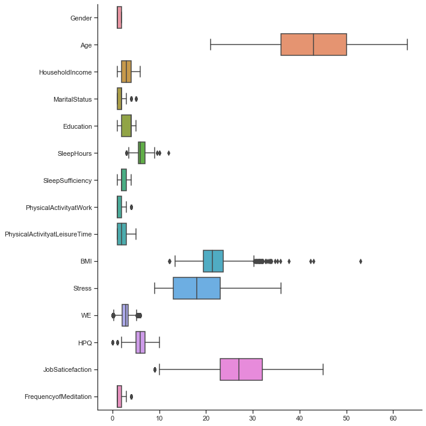

```python
sns.catplot(data=JP2, orient="h", height= 10, kind="box");
```

**Another aspect of study is to find out will meditation help for sleep sufficiency**

- From 4.2 Seaborn, the result pointed out one of the popular words is "sleep", so I focus the data related to sleep.
- In the following graph, x axis represent sleep sufficiency, y axis represent the sleeping hours, hue represent the frequency of meditation where 1 = the least practice, 4 = the more practice.

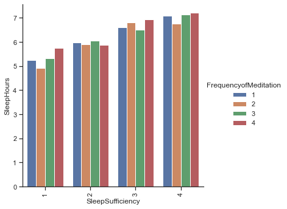

```python
sns.catplot(kind="bar", x="SleepSufficiency", y="SleepHours", hue="FrequencyofMeditation", ci=None,  data=JP2)
plt.xticks(rotation=90)
plt.show()
```

The bar graph demonstrates that overall sleep sufficiency increases as we sleep more. It appears that practicing meditation frequently has little to no impact on getting enough sleep.

## 6 Summary

**6.1 Summary of prepared data**

The summary from 5 datasets, there were two datasets about meditation app reviews, two dataset about the relationship between meditation and the work performance, and one about the relationship between meditation and the brain wave change.

**To response to the objective to this project:**

1)Measuring attitude - how much positive and negative emotional language is in reviews?

- Users of the meditation app respond in terms of position, according to the sentiment analysis.

2)Politeness - utilizing hedging phrases for response

- For both app platforms, the most frequent, polite terms are "love," "like," and "app."

3)Is the user really enjoying and find it useful when using the mediation application?

- The 5 most common word for Google Play Store Meditation App Reviews are: [('app', 483), ('love', 132), ('good', 117), ('really', 113), ('This', 99)],
- The 5 most common word for App Store Meditation App Reviews are: [('app', 2177), ('sleep', 878), ('Calm', 701), ('like', 579), ('stories', 555)]
- According to the frequency distributions, the user enjoys using the meditation app.

**6.2 Conclusions**

According to the aforementioned report, there is a market for meditation as more individuals choose to use natural approaches to maintain the health of their bodies.

My understanding of how to create a data analysis proposal has improved by the assignment, which will be useful for my final project. It is an excellent start to combine the knowledge I already have with computer science methodology to explore some intriguing insight, particularly the topic related to health and wellbeing as a yoga teacher.

## 7 References and Resources

### 7.1 References

[1] Koichiro Shiba ,Masahiro Nishimoto ,Minami Sugimoto,Yoshiki Ishikawa. (2015, May 29). The Association between Meditation Practice and Job Performance: A Cross-Sectional Study [Online]. Available: https://journals.plos.org/plosone/article?id=10.1371/journal.pone.0128287  
[2] Claire Braboszcz ,B. Rael Cahn,Jonathan Levy,Manuel Fernandez,Arnaud Delorme. (2017, January 24). Increased Gamma Brainwave Amplitude Compared to Control in Three Different Meditation Traditions [Online]. Available: https://journals.plos.org/plosone/article?id=10.1371/journal.pone.0170647  
[3] P. Petchsawanga, "Workplace Spirituality, Meditation, and Work Performance", Journal of Management, Spirituality & Religion 9:2, pp. 189- 208, June 2012 [Online]. Available: https://www.researchgate.net/publication/254334245_Workplace_Spirituality_Meditation_and_Work_Performance  
[4] Mira Rakicevic. (2022, January 3). 27 Meditation Statistics for Your Well-Being in 2022 [Online]. Available: https://disturbmenot.co/meditation-statistics/  
[5] Zuckerman. (2020, May 22). 46 MEDITATION STATISTICS: 2020/2021 BENEFITS, MARKET VALUE & TRENDS [Online]. Available: https://comparecamp.com/meditation-statistics/#TOC1  
[6] DELAL TOMRUK. (2021, June 22). Google Play Store Meditation App Reviews [Online]. Available: https://www.kaggle.com/datasets/dtomruk/google-play-store-meditation-app-reviews?resource=download  
[7] DELAL TOMRUK. (2021, June 22). App Store Meditation App Reviews [Online]. Available: https://www.kaggle.com/datasets/dtomruk/app-store-meditation-app-reviews

### 7.2 Resources used

**Data cleaning and processing, feature generation**

- Natural Language Processing lab, Dr Sean McGrath
- Nltk lab, Dr Sean McGrath
- nltk.org(2022, June 12), Natural Language Toolkit, [Online]. Available:https://www.nltk.org/
- M.Siddharth(2021, July 17), NLTK: A Beginners Hands-on Guide to Natural Language Processing, [Online]. Available: https://www.analyticsvidhya.com/blog/2021/07/nltk-a-beginners-hands-on-guide-to-natural-language-processing/
- D.Vu(2019, November 8),datacamp.com, Generating WordClouds in Python Tutorial, [Online]. Available: https://www.datacamp.com/tutorial/wordcloud-python
- J.Kirenz (2022, May 19) Text Mining and Sentiment Analysis with NLTK and pandas in Python [Online]. Available:https://www.kirenz.com/post/2021-12-11-text-mining-and-sentiment-analysis-with-nltk-and-pandas-in-python/text-mining-and-sentiment-analysis-with-nltk-and-pandas-in-python/

**Exploratory data analysis**

- Matplotlib Essentials lab, Dr Sean McGrath
- Seaborn Essentials lab, Dr Sean McGrath
- w3schools.com(2022, May 29), NumPy Introduction, [Online]. Available:https://www.w3schools.com/python/numpy/numpy_intro.asp
- w3schools.com(2022, May 30), Pandas Tutorial, [Online]. Available: https://www.w3schools.com/python/pandas/default.asp
- w3schools.com(2022, May 28), Matplotlib Pyplot, [Online]. Available:https://www.w3schools.com/python/matplotlib_pyplot.asp
- w3schools.com(2022, May 28), Visualize Distributions With Seaborn, [Online]. Available:https://www.w3schools.com/python/numpy/numpy_random_seaborn.asp
- J.Kirenz (2022, May 19) Text Mining and Sentiment Analysis with NLTK and pandas in Python [Online]. Available:https://www.kirenz.com/post/2021-12-11-text-mining-and-sentiment-analysis-with-nltk-and-pandas-in-python/text-mining-and-sentiment-analysis-with-nltk-and-pandas-in-python/